# ECON 320 — Econometrics Lab

## Model Estimation Workshop (Group Work)

> Work **with the same groups** you formed for your research proposal. Today you'll (i) load your chosen data, (ii) state your hypothesis and whether it's causal or correlational, (iii) inspect multicollinearity, (iv) estimate your model and produce a results table, and (v) interpret the estimates.

### 👥 Group Members (3–5 people)

Write the full names **of the present** members and lab in parentheses.

**Your group:**  
Howie Brown Ashely Mazarin Eshan Momin Caleigh Shapiro

```python
# 🧰 Setup — common packages (add more as needed)
import pandas as pd
import numpy as np
import matplotlib.pyplot as plt

# Econometrics
import statsmodels.api as sm
import statsmodels.formula.api as smf

# Display options
pd.set_option('display.max_columns', 100)
pd.set_option('display.width', 120)

%matplotlib inline
```

## ✍️ Exercise 1 — Load your data into a pandas DataFrame

Load the dataset you plan to use for your **research proposal** into a pandas DataFrame so that the **outcome (Y)** and **regressors (X's)** are columns.

- If you're **continuing with the same dataset** from the previous handout, you can **recycle your code**.
- If you **changed datasets**, you will likely need to **write new loading code from scratch**. Consider asking an LLM for quick steps (e.g., *"How to import file type `_____` into a pandas DataFrame in Python?"*).

Keep the DataFrame named **`df`**.

```python
# ⬇️ Replace with your file path + loader of choice, then assign to df
data_path = '/Users/eshanmomin/Desktop/MAIN/Emory_Junior_2025/ECON320/Week 7/usa_00004.csv'  # e.g., 'data/myfile.csv'

# Examples — uncomment and edit ONE:
df = pd.read_csv(data_path)
# df = pd.read_excel(data_path, sheet_name=0)
# df = pd.read_json(data_path)
# df = pd.read_parquet(data_path)

# TODO: ensure df is defined
try:
    display(df.head())
except NameError:
    print('Define your DataFrame as df, then re-run this cell.')
```

|  | YEAR | SAMPLE | SERIAL | CBSERIAL | HHWT | CLUSTER | STRATA | GQ | HHINCOME | VALUEH | PERNUM | PERWT | AGE | EDUC | EDUCD | MOVEDIN |
| --- | --- | --- | --- | --- | --- | --- | --- | --- | --- | --- | --- | --- | --- | --- | --- | --- |
| 0 | 2023 | 202301 | 1 | 2023010000113 | 6.0 | 2023000000011 | 280201 | 3 | 9999999 | 9999999 | 1 | 6.0 | 86 | 6 | 63 | 0 |
| 1 | 2023 | 202301 | 2 | 2023010000180 | 27.0 | 2023000000021 | 10001 | 3 | 9999999 | 9999999 | 1 | 27.0 | 60 | 6 | 63 | 0 |
| 2 | 2023 | 202301 | 3 | 2023010000181 | 47.0 | 2023000000031 | 40201 | 4 | 9999999 | 9999999 | 1 | 47.0 | 20 | 7 | 71 | 0 |
| 3 | 2023 | 202301 | 4 | 2023010000250 | 11.0 | 2023000000041 | 270201 | 3 | 9999999 | 9999999 | 1 | 11.0 | 13 | 2 | 26 | 0 |
| 4 | 2023 | 202301 | 5 | 2023010000340 | 57.0 | 2023000000051 | 280201 | 4 | 9999999 | 9999999 | 1 | 57.0 | 18 | 6 | 65 | 0 |

## 🔎 Exercise 2 — State your hypothesis and clarify causality vs correlation

1. **State your hypothesis** in a single sentence. **Example (illustrative only):**

If a household’s income and education level increase, the value of their owned home will also increase, controlling for the age of the householder.

2. Is your research question about a **causal relationship** (does X *cause* changes in Y?) or about a **correlation/association** (X and Y move together without a causal claim)?  
   We emphasized this distinction in lecture—be explicit here.

Our research question investigates a correlation/association, not a causal relationship.

While higher income and education are expected to be associated with higher home values, this regression does not establish causality because other unobserved factors—such as neighborhood quality, housing market conditions, or credit access—may influence both income and home value. Therefore, the model identifies patterns of association rather than definitive cause-and-effect relationships.

> We will soon test your pre-assumption against the data. Keep your statement clear and falsifiable.

## 🧩 Exercise 3 — Visual multicollinearity check (correlation matrix)

- Build a **correlation matrix** among your **regressors (X's)**.
- Display it as a **color-coded heatmap**: values near **-1** are toward one end of the scale; values near **+1** are toward the other.
- Also **inspect the numeric values** and **flag any pair** of regressors with absolute correlation **> 0.8** as a potential multicollinearity issue.

**Why it matters (summary):** Multicollinearity can inflate the **variance of the OLS estimator**. As a result, coefficients may appear **statistically insignificant** even if there is a real effect when predictors are not so collinear.

**Report:** List any problematic regressor pairs you find (or write that there is no evident multicollinearity).

```
📈 Correlation Matrix:

          HHINCOME   AGE  EDUC
HHINCOME      1.00 -0.14  0.11
AGE          -0.14  1.00  0.53
EDUC          0.11  0.53  1.00

⚠️  Potential multicollinearity (|r| > 0.8):
✅ No evident multicollinearity found.
```

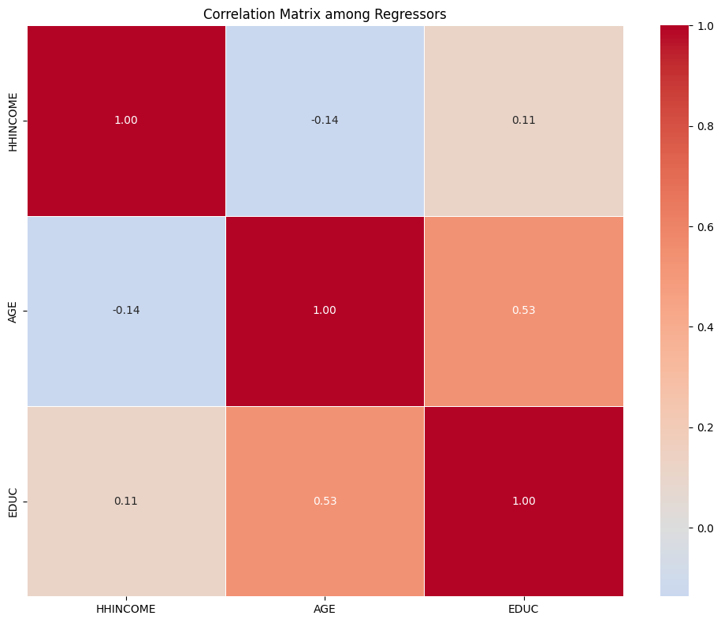

```python
# your code here
import pandas as pd
import matplotlib.pyplot as plt
import seaborn as sns
from itertools import combinations

INPUT_PATH = "/Users/eshanmomin/Desktop/MAIN/Emory_Junior_2025/ECON320/Week 7/usa_00004_cleaned.csv"

# Load dataset
df = pd.read_csv(INPUT_PATH)

# Define regressors to check
regressors = [
    "HHINCOME", "AGE", "EDUC"
]

# Keep only columns that exist in your data
regressors = [r for r in regressors if r in df.columns]
corr = df[regressors].corr(numeric_only=True)

# ============================================
# ======== PRINT AND FLAG HIGH CORR ==========
# ============================================
print("\n📈 Correlation Matrix:\n")
print(corr.round(2))

# Flag pairs with |r| > 0.8
print("\n⚠️  Potential multicollinearity (|r| > 0.8):")
problematic_pairs = []
for a, b in combinations(regressors, 2):
    r = corr.loc[a, b]
    if abs(r) > 0.8:
        print(f" - {a} and {b}: {r:.2f}")
        problematic_pairs.append((a, b, r))

if not problematic_pairs:
    print("✅ No evident multicollinearity found.")

# ============================================
# ============ HEATMAP VISUAL ================
# ============================================
plt.figure(figsize=(10, 8))
sns.heatmap(
    corr,
    annot=True,
    fmt=".2f",
    cmap="coolwarm",
    center=0,
    linewidths=0.5
)
plt.title("Correlation Matrix among Regressors")
plt.tight_layout()
plt.show()
```

## 📊 Exercise 4 — Estimate your model and output a regression table

Run an OLS regression of your chosen **outcome (Y)** on your **regressors (X's)** and display a **results table**.

- If your data need re-organization (e.g., categorical dummies, transformations), do that first.
- As always, if you get stuck, ask the **instructor** for guidance.

You can use a **formula** (e.g., `Y ~ X1 + X2`) or a matrix specification (`add_constant` + arrays).

```python
# your code here


import pandas as pd
import statsmodels.api as sm
import statsmodels.formula.api as smf

# =====================================================
# ================= LOAD DATA =========================
# =====================================================
df = pd.read_csv("/Users/eshanmomin/Desktop/MAIN/Emory_Junior_2025/ECON320/Week 7/usa_00004_cleaned.csv")

# Keep only needed columns (drop missing)
cols = ["VALUEH", "HHINCOME", "AGE", "EDUC"]
df = df[[c for c in cols if c in df.columns]].dropna()

# =====================================================
# ============== RUN OLS REGRESSION ===================
# =====================================================

# Using formula notation (easier and cleaner)
model = smf.ols("VALUEH ~ HHINCOME + AGE + EDUC", data=df).fit()

# =====================================================
# ============== DISPLAY RESULTS ======================
# =====================================================
print(model.summary())

# Optional: export regression table to CSV
results_df = pd.DataFrame({
    "Variable": model.params.index,
    "Coefficient": model.params.values,
    "Std. Error": model.bse.values,
    "t-Statistic": model.tvalues.values,
    "p-Value": model.pvalues.values
})
results_df.to_csv("/Users/eshanmomin/Downloads/regression_results.csv", index=False)
print("\n✅ Regression table saved to regression_results.csv")
```

```
                            OLS Regression Results
==============================================================================
Dep. Variable:                 VALUEH   R-squared:                       0.150
Model:                            OLS   Adj. R-squared:                  0.150
Method:                 Least Squares   F-statistic:                 1.439e+05
Date:                Sat, 11 Oct 2025   Prob (F-statistic):               0.00
Time:                        23:35:42   Log-Likelihood:            -3.5827e+07
No. Observations:             2439255   AIC:                         7.165e+07
Df Residuals:                 2439251   BIC:                         7.165e+07
Df Model:                           3
Covariance Type:            nonrobust
==============================================================================
                 coef    std err          t      P>|t|      [0.025      0.975]
------------------------------------------------------------------------------
Intercept   1.673e+05    986.072    169.658      0.000    1.65e+05    1.69e+05
HHINCOME       1.7300      0.003    624.379      0.000       1.725       1.735
AGE          270.1752     18.656     14.482      0.000     233.610     306.740
EDUC        7975.3246    135.817     58.721      0.000    7709.129    8241.521
==============================================================================
Omnibus:                  2889458.732   Durbin-Watson:                   0.689
Prob(Omnibus):                  0.000   Jarque-Bera (JB):        410547979.588
Skew:                           6.303   Prob(JB):                         0.00
Kurtosis:                      65.294   Cond. No.                     5.32e+05
==============================================================================

Notes:
[1] Standard Errors assume that the covariance matrix of the errors is correctly specified.
[2] The condition number is large, 5.32e+05. This might indicate that there are
strong multicollinearity or other numerical problems.

✅ Regression table saved to regression_results.csv
```

## 🧠 Exercise 5 — Interpret the coefficients

Based on your results table:

1. Interpret the **key coefficients** in **context** (units, sign, and practical magnitude).
2. Do the observed **effects/relationships** align with your **hypothesis** from Exercise 2?
3. Briefly note any **surprises** or **concerns** (e.g., sign flips under multicollinearity, wide confidence intervals, model fit).

Keep this concise and decision-oriented; you’ll refine and expand in your proposal.

Key Coefficients

Household Income (HHINCOME): The coefficient of 1.73 means that, holding other factors constant, each additional $1 of household income is associated with about $1.73 higher reported home value. The positive and highly significant effect (p < 0.001) supports the idea that wealthier households own higher-value homes.

Age of Householder (AGE): Each extra year of age corresponds to roughly $270 higher home value, controlling for income and education. This small but positive effect may reflect accumulated wealth or ownership of older, paid-off properties.

Education Level (EDUC): For each higher education category (e.g., moving from high-school → some college → bachelor’s), home value rises by about $7,975. This strong, significant relationship suggests that more-educated householders occupy more expensive homes, consistent with higher lifetime earnings and financial literacy.

Alignment with Hypothesis These results align closely with the earlier hypothesis that higher income and education are associated with higher home values, even after accounting for age. All key predictors have the expected positive signs and are statistically significant.

Surprises or Concerns

The R-squared = 0.15 indicates that the model explains about 15 percent of variation in home values—reasonable for socioeconomic data but suggesting that structural (e.g., rooms, year built) and geographic factors still play large roles.

Residual diagnostics (Durbin-Watson ≈ 0.69, high skew/kurtosis) show non-normal residuals, common with large-scale income and housing data, hinting that log-transforming skewed variables could improve model fit.

### ✅ Quick Checklist

- Group names + lab (3–5 people) completed
- Data loaded into `df`
- Hypothesis written; causal vs correlation clarified
- Correlation matrix inspected; multicollinearity issues (if any) reported
- Regression estimated; results interpreted

ECON320 Python Programming Laboratory

Instructor *Guido Anthony Romero*

*guido.romero@emory.edu*

Department of Economics

Emory University